# 05_CNN

**CNN**

By Prof. Seungchul Lee  
http://iai.postech.ac.kr/  
Industrial AI Lab at POSTECH

Table of Contents

```python
# Import libraries
import numpy as np
import matplotlib.pyplot as plt
from scipy.misc import imread, imresize
from scipy.signal import convolve2d
from six.moves import cPickle
import skimage

% matplotlib inline
```

# 1. Convolutional Neural Networks (CNN)

## 1.1. Motivation

The bird occupies a local area and looks the same in different parts of an image. We should construct neural networks which exploit these properties.

[figure not shown]

- Generic structure of neural network
  - does not seem the best
  - did not make use of the fact that we are dealing with images
  - no regularization

[figure not shown]

## 1.2. Convolutional Operator

**Matrix multiplication**

- Every output unit interacts with every interacts unit

[figure not shown]

**Convolution**

- Local connectivity
- Weight sharing
- Typically have sparse interactions

[figure not shown]

**Convolutional Neural Networks**

- Simply neural networks that use the convolution in place of general matrix multiplication in at least one of their layers
- The convolution can be interpreted as an element-wise matrix multiplication

[figure not shown]

## 1.4. Pooling

- Compute a maximum value in a sliding window (max pooling)
  - Reduce spatial resolution for faster computation
  - Achieve invariance to local translation
- Pooling size : $2\times2$

[figure not shown]

- Max pooling introduces invariances

[figure not shown]

# 2. Lab: CNN with TensorFlow

- MNIST example
- To classify handwritten digits

[figure not shown]

## 2.1. Import Library

```python
# Import Library
import numpy as np
import matplotlib.pyplot as plt
import tensorflow as tf
```

## 2.2. Load MNIST Data

- Download MNIST data from the tensorflow tutorial example

```python
from tensorflow.examples.tutorials.mnist import input_data
mnist = input_data.read_data_sets("MNIST_data/", one_hot=True)
```

```
Successfully downloaded train-images-idx3-ubyte.gz 9912422 bytes.
Extracting MNIST_data/train-images-idx3-ubyte.gz
Successfully downloaded train-labels-idx1-ubyte.gz 28881 bytes.
Extracting MNIST_data/train-labels-idx1-ubyte.gz
Successfully downloaded t10k-images-idx3-ubyte.gz 1648877 bytes.
Extracting MNIST_data/t10k-images-idx3-ubyte.gz
Successfully downloaded t10k-labels-idx1-ubyte.gz 4542 bytes.
Extracting MNIST_data/t10k-labels-idx1-ubyte.gz
```

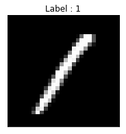

```python
# Check data
train_x, train_y = mnist.train.next_batch(10)
img = train_x[9,:].reshape(28, 28)

plt.figure(figsize=(5, 3))
plt.imshow(img,'gray')
plt.title("Label : {}".format(np.argmax(train_y[9])))
plt.xticks([])
plt.yticks([])
plt.show()
```

## 2.3. Build a Model

**Convolution layers**

- First, the layer performs several convolutions to produce a set of linear activations
- Second, each linear activation is running through a nonlinear activation function
- Third, use pooling to modify the output of the layer further

**Fully connected layers**

- Simple multi-layer perceptrons

[figure not shown]

**First, the layer performs several convolutions to produce a set of linear activations**

[figure not shown]

- Filter size : $3\times3$
- Stride : The stride of the sliding window for each dimension of input
- Padding : Allow us to control the kernel width and the size of the output independently
  - `'SAME'` : zero padding
  - `'VALID'` : No padding

```
conv1 = tf.nn.conv2d(x, weights['conv1'], strides= [1,1,1,1], padding = 'SAME')
```

**Second, each linear activation is running through a nonlinear activation function**

[figure not shown]

```
conv1 = tf.nn.relu(tf.add(conv1, biases['conv1']))
```

**Third, use a pooling to modify the output of the layer further**

- Compute a maximum value in a sliding window (max pooling)

[figure not shown]

- Pooling size : $2\times2$

```
maxp1 = tf.nn.max_pool(conv1,
                       ksize = [1, p1_h, p1_w, 1],
                       strides = [1, p1_h, p1_w, 1],
                       padding ='VALID')
```

**Fully connected layer**

- Input is typically in a form of flattened features
- Then, apply `softmax` to multiclass classification problems
- The output of the softmax function is equivalent to a categorical probability distribution, it tells you the probability that any of the classes are true.

[figure not shown]

```
output = tf.add(tf.matmul(hidden1, weights['output']), biases['output'])
```

## 2.4. Define a CNN's Shape

```python
input_h = 28 # Input height
input_w = 28 # Input width
input_ch = 1 # Input channel : Gray scale
# (None, 28, 28, 1)

## First convolution layer
# Filter size
k1_h = 3
k1_w = 3
# the number of channels
k1_ch = 32
# Pooling size
p1_h = 2
p1_w = 2
# (None, 14, 14 ,32)

## Second convolution layer
# Filter size
k2_h = 3
k2_w = 3
# the number of channels
k2_ch = 64
# Pooling size
p2_h = 2
p2_w = 2
# (None, 7, 7 ,64)

## Fully connected
# Flatten the features
# -> (None, 7*7*64)
conv_result_size = int((28/(2*2)) * (28/(2*2)) * k2_ch)
n_hidden1 = 100
n_output = 10
```

## 2.5. Define Weights, Biases and Network

- Define parameters based on predefined layer size
- Initialize with normal distribution with $\mu = 0$ and $\sigma = 0.1$

```python
weights = {
    'conv1' : tf.Variable(tf.random_normal([k1_h, k1_w, input_ch, k1_ch],stddev = 0.1)),
    'conv2' : tf.Variable(tf.random_normal([k2_h, k2_w, k1_ch, k2_ch],stddev = 0.1)),
    'hidden1' : tf.Variable(tf.random_normal([conv_result_size, n_hidden1], stddev = 0.1)),
    'output' : tf.Variable(tf.random_normal([n_hidden1, n_output], stddev = 0.1))
}

biases = {
    'conv1' : tf.Variable(tf.random_normal([k1_ch], stddev = 0.1)),
    'conv2' : tf.Variable(tf.random_normal([k2_ch], stddev = 0.1)),
    'hidden1' : tf.Variable(tf.random_normal([n_hidden1], stddev = 0.1)),
    'output' : tf.Variable(tf.random_normal([n_output], stddev = 0.1))
}

x = tf.placeholder(tf.float32, [None, input_h, input_w, input_ch])
y = tf.placeholder(tf.float32, [None, n_output])
```

```python
# Define Network
def net(x, weights, biases):
    ## First convolution layer
    conv1 = tf.nn.conv2d(x, weights['conv1'],
                         strides= [1, 1, 1, 1],
                         padding = 'SAME')
    conv1 = tf.nn.relu(tf.add(conv1, biases['conv1']))
    maxp1 = tf.nn.max_pool(conv1,
                           ksize = [1, p1_h, p1_w, 1],
                           strides = [1, p1_h, p1_w, 1],
                           padding = 'VALID'
                           )

    ## Second convolution layer
    conv2 = tf.nn.conv2d(maxp1, weights['conv2'],
                         strides= [1, 1, 1, 1],
                         padding = 'SAME')
    conv2 = tf.nn.relu(tf.add(conv2, biases['conv2']))
    maxp2 = tf.nn.max_pool(conv2,
                           ksize = [1, p2_h, p2_w, 1],
                           strides = [1, p2_h, p2_w, 1],
                           padding = 'VALID')

    # shape = conv2.get_shape().as_list()
    # maxp2_re = tf.reshape(conv2, [-1, shape[1]*shape[2]*shape[3]])
    maxp2_re = tf.reshape(maxp2, [-1, conv_result_size])

    ### Fully connected
    hidden1 = tf.add(tf.matmul(maxp2_re, weights['hidden1']), biases['hidden1'])
    hidden1 = tf.nn.relu(hidden1)
    output = tf.add(tf.matmul(hidden1, weights['output']), biases['output'])
    return output
```

## 2.6. Define Loss, Initializer and Optimizer

**Loss**

- Classification: Cross entropy
  - Equivalent to apply logistic regression

$$ -\frac{1}{N}\sum_{i=1}^{N}y^{(i)}\log(h_{\theta}\left(x^{(i)}\right)) + (1-y^{(i)})\log(1-h_{\theta}\left(x^{(i)}\right)) $$

**Initializer**

- Initialize all the empty variables

**Optimizer**

- GradientDescentOptimizer
- AdamOptimizer: the most popular optimizer

```python
LR = 0.0001

pred = net(x, weights, biases)
loss = tf.nn.softmax_cross_entropy_with_logits(labels=y, logits=pred)
loss = tf.reduce_mean(loss)

# optimizer = tf.train.GradientDescentOptimizer(learning_rate).minimize(cost)
optm = tf.train.AdamOptimizer(LR).minimize(loss)

init = tf.global_variables_initializer()
```

[output not shown]

## 2.8. Define Configuration

- Define parameters for training CNN
  - `n_batch` : batch size for stochastic gradient descent
  - `n_iter` : the number of training steps
  - `n_prt` : check loss for every `n_prt` iteration

```python
n_batch = 50
n_iter = 2500
n_prt = 250
```

## 2.9. Optimization

```python
# Run initialize
# config = tf.ConfigProto(allow_soft_placement=True)  # GPU Allocating policy
# sess = tf.Session(config=config)
sess = tf.Session()
sess.run(init)

# Training cycle
for epoch in range(n_iter):
    train_x, train_y = mnist.train.next_batch(n_batch)
    train_x = np.reshape(train_x, [-1, input_h, input_w, input_ch])
    sess.run(optm, feed_dict={x: train_x,  y: train_y})

    if epoch % n_prt == 0:
        c = sess.run(loss, feed_dict={x: train_x, y: train_y})
        print ("Iter : {}".format(epoch))
        print ("Cost : {}".format(c))
```

```
Iter : 0
Cost : 2.477311134338379
Iter : 250
Cost : 0.5830925107002258
Iter : 500
Cost : 0.27900442481040955
Iter : 750
Cost : 0.23792098462581635
Iter : 1000
Cost : 0.2580292522907257
Iter : 1250
Cost : 0.17785848677158356
Iter : 1500
Cost : 0.10052787512540817
Iter : 1750
Cost : 0.13824580609798431
Iter : 2000
Cost : 0.16196481883525848
Iter : 2250
Cost : 0.03796611353754997
```

## 2.10. Test

```python
test_x, test_y = mnist.test.next_batch(100)

my_pred = sess.run(pred, feed_dict={x : test_x.reshape(-1, 28, 28, 1)})
my_pred = np.argmax(my_pred, axis=1)

labels = np.argmax(test_y, axis=1)

accr = np.mean(np.equal(my_pred, labels))
print("Accuracy : {}%".format(accr*100))
```

```
Accuracy : 99.0%
```

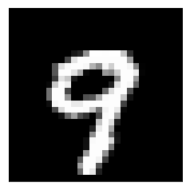

```
Prediction : 9
```

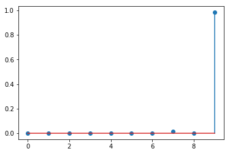

```
Probability : [0.   0.   0.   0.   0.   0.   0.   0.02 0.   0.98]
```

```python
test_x, test_y = mnist.test.next_batch(1)
logits = sess.run(tf.nn.softmax(pred), feed_dict={x : test_x.reshape(-1, 28, 28, 1)})
predict = np.argmax(logits)

plt.imshow(test_x.reshape(28, 28), 'gray')
plt.xticks([])
plt.yticks([])
plt.show()

print('Prediction : {}'.format(predict))

plt.stem(logits.ravel())
plt.show()

np.set_printoptions(precision=2, suppress=True)
print('Probability : {}'.format(logits.ravel()))
```

```python
%%javascript
$.getScript('https://kmahelona.github.io/ipython_notebook_goodies/ipython_notebook_toc.js')
```